# Biostat 203B Homework 5

Due Mar 22 @ 11:59PM

Author

Puyuan Liu, 806152535

# Predicting ICU duration

Using the ICU cohort `mimiciv_icu_cohort.rds` you built in Homework 4, develop at least three machine learning approaches (logistic regression with enet regularization, random forest, boosting, SVM, MLP, etc) plus a model stacking approach for predicting whether a patient’s ICU stay will be longer than 2 days. You should use the `los_long` variable as the outcome. Your algorithms can use patient demographic information (gender, age at ICU `intime`, marital status, race), ICU admission information (first care unit), the last lab measurements before the ICU stay, and first vital measurements during ICU stay as features. You are welcome to use any feature engineering techniques you think are appropriate; but make sure to not use features that are not available at an ICU stay’s `intime`. For instance, `last_careunit` cannot be used in your algorithms.

## 1. Data preprocessing and feature engineering.

```r
icu_cohort <- read_rds("~/203b-hw/hw4/mimiciv_shiny/mimic_icu_cohort.rds")
```

```r
# Define a function to removes out-liers based on IQR
remove_outliers_iqr <- function(data_vector) {
  # Calculate the first and third quartiles (Q1, Q3) and the IQR
  quartiles <- quantile(data_vector, probs = c(0.25, 0.75), na.rm = TRUE)
  iqr_value <- IQR(data_vector, na.rm = TRUE)
  # Replace out-liers with NA
  cleaned_vector <- dplyr::if_else(
    data_vector < quartiles[1] - 1.5 * iqr_value |
    data_vector > quartiles[2] + 1.5 * iqr_value,
    NA,
    data_vector
  )
  # Return the vector with outliers replaced by NA
  return(cleaned_vector)
}


# Data preprocessing and feature engineering
mimic_icu_cohort <- icu_cohort |>

  # Select columns of interest
  select(subject_id, hadm_id, stay_id, los_long, first_careunit, admission_type,
         marital_status, race, gender, age, insurance,
         Sodium, Chloride, Creatinine, Potassium, Glucose, Hematocrit,
         `White Blood Cells`, Bicarbonate,
         `Temperature Fahrenheit`, `Non Invasive Blood Pressure diastolic`,
         `Respiratory Rate`, `Non Invasive Blood Pressure systolic`,
         `Heart Rate`) |>

  # Convert character and logical columns to factors
  mutate_if(is.character, as.factor) |>
  mutate_if(is.logical, as.factor) |>

  # Apply the remove_outliers_iqr function to numeric columns
  mutate_if(is.numeric, remove_outliers_iqr) |>

  # Impute NA's in numerical columns with the median
  mutate(across(where(is.numeric),
                ~if_else(is.na(.),
                         median(., na.rm = TRUE), .))) |>
  print(width = Inf)
```

```
# A tibble: 73,181 × 24
   subject_id  hadm_id  stay_id los_long
        <int>    <int>    <int> <fct>
 1   10000032 29079034 39553978 FALSE
 2   10000980 26913865 39765666 FALSE
 3   10001217 24597018 37067082 FALSE
 4   10001217 27703517 34592300 FALSE
 5   10001725 25563031 31205490 FALSE
 6   10001884 26184834 37510196 TRUE
 7   10002013 23581541 39060235 FALSE
 8   10002155 20345487 32358465 FALSE
 9   10002155 23822395 33685454 TRUE
10   10002155 28994087 31090461 TRUE
   first_careunit                                   admission_type
   <fct>                                            <fct>
```

[output cut: 59 more lines]

## 2. Data partitioning

Partition data into 50% training set and 50% test set. Stratify partitioning according to `los_long`. For grading purpose, sort the data by `subject_id`, `hadm_id`, and `stay_id` and use the seed `203` for the initial data split. Below is the sample code.

```r
set.seed(203)

# sort
mimiciv_icu_cohort <- mimic_icu_cohort |>
  arrange(subject_id, hadm_id, stay_id) |>
  select(-c(subject_id, hadm_id, stay_id))

data_split <- initial_split(
  mimiciv_icu_cohort,
  # stratify by los_long
  strata = "los_long",
  prop = 0.5
  )
```

```r
summary(mimiciv_icu_cohort)
```

```
  los_long                                              first_careunit
 FALSE:38050   Cardiac Vascular Intensive Care Unit (CVICU)    :11582
 TRUE :35131   Medical Intensive Care Unit (MICU)              :15898
               Medical/Surgical Intensive Care Unit (MICU/SICU):12733
               Surgical Intensive Care Unit (SICU)             :11161
               Other                                           :21807

                     admission_type   marital_status        race
 EW EMER.                   :38672   DIVORCED: 5404   Other   :10756
 OBSERVATION ADMIT          : 8974   MARRIED :32768   ASIAN   : 2155
 SURGICAL SAME DAY ADMISSION: 7373   SINGLE  :20858   BLACK   : 7960
 URGENT                     :12453   WIDOWED : 9038   HISPANIC: 2741
 Other                      : 5709   NA's    : 5113   WHITE   :49569

 gender         age            insurance         Sodium         Chloride
 F:32363   Min.   : 20.00   Medicaid: 5528   Min.   :129.0   Min.   : 88.0
 M:40818   1st Qu.: 55.00   Medicare:33091   1st Qu.:137.0   1st Qu.: 99.0
           Median : 66.00   Other   :34562   Median :139.0   Median :102.0
           Mean   : 64.82                    Mean   :138.5   Mean   :101.6
           3rd Qu.: 77.00                    3rd Qu.:140.0   3rd Qu.:104.0
           Max.   :102.00                    Max.   :148.0   Max.   :115.0
   Creatinine      Potassium        Glucose      Hematocrit
 Min.   :0.000   Min.   :2.600   Min.   : 14   Min.   :14.30
 1st Qu.:0.800   1st Qu.:3.900   1st Qu.:102   1st Qu.:30.20
 Median :0.900   Median :4.200   Median :116   Median :35.20
 Mean   :1.023   Mean   :4.202   Mean   :123   Mean   :34.86
 3rd Qu.:1.200   3rd Qu.:4.500   3rd Qu.:136   3rd Qu.:39.60
 Max.   :2.500   Max.   :5.700   Max.   :241   Max.   :55.40
 White Blood Cells  Bicarbonate    Temperature Fahrenheit
 Min.   : 0.100    Min.   :15.00   Min.   : 96.00
 1st Qu.: 7.000    1st Qu.:23.00   1st Qu.: 97.70
 Median : 9.000    Median :25.00   Median : 98.10
 Mean   : 9.747    Mean   :24.56   Mean   : 98.15
 3rd Qu.:11.800    3rd Qu.:27.00   3rd Qu.: 98.60
 Max.   :22.700    Max.   :34.00   Max.   :100.30
 Non Invasive Blood Pressure diastolic Respiratory Rate
 Min.   : 24.00                        Min.   : 5.00
 1st Qu.: 57.00                        1st Qu.:15.00
 Median : 67.00                        Median :18.00
 Mean   : 67.82                        Mean   :18.51
 3rd Qu.: 78.00                        3rd Qu.:22.00
 Max.   :112.00                        Max.   :32.00
 Non Invasive Blood Pressure systolic   Heart Rate
 Min.   : 57.0                        Min.   : 34.00
 1st Qu.:106.0                        1st Qu.: 75.00
 Median :121.0                        Median : 86.00
 Mean   :122.3                        Mean   : 87.77
 3rd Qu.:138.0                        3rd Qu.:100.00
 Max.   :188.0                        Max.   :141.00
```

```r
icu_train <- training(data_split)
dim(icu_train)
```

```
[1] 36590    21
```

```r
icu_test <- testing(data_split)
dim(icu_test)
```

```
[1] 36591    21
```

```r
data_split |>
  write_rds("data_split.rds", compress = "gz")
```

## 3. Train and tune the models using the training set.

```r
# set up 3-fold cross-validation
set.seed(203)
folds <- vfold_cv(icu_train, v = 3)
folds
```

```
#  3-fold cross-validation
# A tibble: 3 × 2
  splits                id
  <list>                <chr>
1 <split [24393/12197]> Fold1
2 <split [24393/12197]> Fold2
3 <split [24394/12196]> Fold3
```

### Logistic regression with enet regularization

```r
logit_recipe <-
  recipe(
    los_long ~ .,
    data = icu_train
  ) |>
  # mode imputation for categorical_var
  step_impute_mode(all_nominal_predictors()) |>
  # create traditional dummy variables
  step_dummy(all_nominal_predictors()) |>
  # zero-variance filter
  step_zv(all_numeric_predictors()) |>
  # center and scale numeric data
  step_normalize(all_numeric_predictors())
logit_recipe
```

```
── Recipe ──────────────────────────────────────────────────────────────────────
```

```
── Inputs
```

```
Number of variables by role
```

```
outcome:    1
predictor: 20
```

```
── Operations
```

```
• Mode imputation for: all_nominal_predictors()
```

```
• Dummy variables from: all_nominal_predictors()
```

```
• Zero variance filter on: all_numeric_predictors()
```

```
• Centering and scaling for: all_numeric_predictors()
```

```r
# Models
logit_mod <-
  logistic_reg(
    penalty = tune(),
    mixture = tune()
  ) |>
  set_engine("glmnet", standardize = FALSE)
logit_mod
```

```
Logistic Regression Model Specification (classification)

Main Arguments:
  penalty = tune()
  mixture = tune()

Engine-Specific Arguments:
  standardize = FALSE

Computational engine: glmnet
```

```r
# Workflow
logit_wf <- workflow() |>
  add_recipe(logit_recipe) |>
  add_model(logit_mod)
logit_wf
```

```
══ Workflow ════════════════════════════════════════════════════════════════════
Preprocessor: Recipe
Model: logistic_reg()

── Preprocessor ────────────────────────────────────────────────────────────────
4 Recipe Steps

• step_impute_mode()
• step_dummy()
• step_zv()
• step_normalize()

── Model ───────────────────────────────────────────────────────────────────────
Logistic Regression Model Specification (classification)

Main Arguments:
  penalty = tune()
  mixture = tune()

Engine-Specific Arguments:
  standardize = FALSE

Computational engine: glmnet
```

```r
# Tuning grid
logit_param_grid <- grid_regular(
  penalty(range = c(-2.5, -2)),
  mixture(),
  levels = c(5, 2)
  )
logit_param_grid
```

```
# A tibble: 10 × 2
   penalty mixture
     <dbl>   <dbl>
 1 0.00316       0
 2 0.00422       0
 3 0.00562       0
 4 0.00750       0
 5 0.01          0
 6 0.00316       1
 7 0.00422       1
 8 0.00562       1
 9 0.00750       1
10 0.01          1
```

```r
# Fit cross-validation (logistic)
if (file.exists("logit_fit.rds")) {
  logit_fit <- read_rds("logit_fit.rds")
} else {
  logit_fit <- logit_wf |>
    tune_grid(
      resamples = folds,
      grid = logit_param_grid,
      metrics = metric_set(roc_auc, accuracy),
      control = control_stack_grid()
      )
  write_rds(logit_fit, "logit_fit.rds")
}
logit_fit
```

```
# Tuning results
# 3-fold cross-validation
# A tibble: 3 × 5
  splits                id    .metrics          .notes           .predictions
  <list>                <chr> <list>            <list>           <list>
1 <split [24393/12197]> Fold1 <tibble [20 × 6]> <tibble [0 × 3]> <tibble>
2 <split [24393/12197]> Fold2 <tibble [20 × 6]> <tibble [0 × 3]> <tibble>
3 <split [24394/12196]> Fold3 <tibble [20 × 6]> <tibble [0 × 3]> <tibble>
```

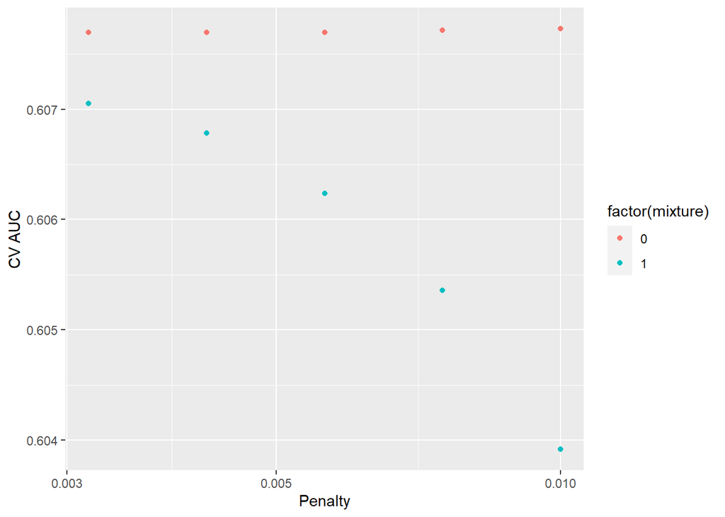

```r
# Visualize CV results
logit_fit |>
  # aggregate metrics from K folds
  collect_metrics() |>
  #print(width = Inf) |>
  filter(.metric == "roc_auc") |>
  ggplot(mapping = aes(x = penalty, y = mean, color = factor(mixture))) +
  geom_point() +
  labs(x = "Penalty", y = "CV AUC") +
  scale_x_log10()
```

```r
logit_fit |>
  show_best("roc_auc")
```

```
# A tibble: 5 × 8
  penalty mixture .metric .estimator  mean     n std_err .config
    <dbl>   <dbl> <chr>   <chr>      <dbl> <int>   <dbl> <chr>
1 0.01          0 roc_auc binary     0.608     3 0.00286 Preprocessor1_Model05
2 0.00750       0 roc_auc binary     0.608     3 0.00281 Preprocessor1_Model04
3 0.00316       0 roc_auc binary     0.608     3 0.00279 Preprocessor1_Model01
4 0.00422       0 roc_auc binary     0.608     3 0.00279 Preprocessor1_Model02
5 0.00562       0 roc_auc binary     0.608     3 0.00279 Preprocessor1_Model03
```

```r
best_logit <- logit_fit |>
  select_best("roc_auc")
best_logit
```

```
# A tibble: 1 × 3
  penalty mixture .config
    <dbl>   <dbl> <chr>
1    0.01       0 Preprocessor1_Model05
```

```r
# Final workflow
logit_final_wf <- logit_wf |>
  finalize_workflow(best_logit)
logit_final_wf
```

```
══ Workflow ════════════════════════════════════════════════════════════════════
Preprocessor: Recipe
Model: logistic_reg()

── Preprocessor ────────────────────────────────────────────────────────────────
4 Recipe Steps

• step_impute_mode()
• step_dummy()
• step_zv()
• step_normalize()

── Model ───────────────────────────────────────────────────────────────────────
Logistic Regression Model Specification (classification)

Main Arguments:
  penalty = 0.01
  mixture = 0

Engine-Specific Arguments:
  standardize = FALSE

Computational engine: glmnet
```

```r
# Fit the whole training set, then predict the test cases
if (file.exists("logit_final_fit.rds")) {
  logit_final_fit <- read_rds("logit_final_fit.rds")
} else {
  logit_final_fit <- logit_final_wf |>
    last_fit(data_split) |>
    write_rds("logit_final_fit.rds")
}
logit_final_fit
```

```
# Resampling results
# Manual resampling
# A tibble: 1 × 6
  splits                id             .metrics .notes   .predictions .workflow
  <list>                <chr>          <list>   <list>   <list>       <list>
1 <split [36590/36591]> train/test sp… <tibble> <tibble> <tibble>     <workflow>
```

```r
# Test metrics
logit_final_fit |>
  collect_metrics()
```

```
# A tibble: 2 × 4
  .metric  .estimator .estimate .config
  <chr>    <chr>          <dbl> <chr>
1 accuracy binary         0.573 Preprocessor1_Model1
2 roc_auc  binary         0.604 Preprocessor1_Model1
```

### Random forest

```r
rf_recipe <-
  recipe(
    los_long ~ .,
    data = icu_train
  ) |>
  # mode imputation for categorical_var
  step_impute_mode(all_nominal_predictors()) |>
  # zero-variance filter
  step_zv(all_numeric_predictors())
rf_recipe
```

```
── Recipe ──────────────────────────────────────────────────────────────────────
```

```
── Inputs
```

```
Number of variables by role
```

```
outcome:    1
predictor: 20
```

```
── Operations
```

```
• Mode imputation for: all_nominal_predictors()
```

```
• Zero variance filter on: all_numeric_predictors()
```

```r
# Model
rf_mod <-
  rand_forest(
    mode = "classification",
    # Number of predictors randomly sampled in each split
    mtry = tune(),
    # Number of trees in ensemble
    trees = tune()
  ) |>
  set_engine("ranger", importance = "impurity")
rf_mod
```

```
Random Forest Model Specification (classification)

Main Arguments:
  mtry = tune()
  trees = tune()

Engine-Specific Arguments:
  importance = impurity

Computational engine: ranger
```

```r
# Workflow
rf_wf <- workflow() |>
  add_recipe(rf_recipe) |>
  add_model(rf_mod)
rf_wf
```

```
══ Workflow ════════════════════════════════════════════════════════════════════
Preprocessor: Recipe
Model: rand_forest()

── Preprocessor ────────────────────────────────────────────────────────────────
2 Recipe Steps

• step_impute_mode()
• step_zv()

── Model ───────────────────────────────────────────────────────────────────────
Random Forest Model Specification (classification)

Main Arguments:
  mtry = tune()
  trees = tune()

Engine-Specific Arguments:
  importance = impurity

Computational engine: ranger
```

```r
# Tuning grid
rf_param_grid <- grid_regular(
  trees(range = c(400L, 600L)),
  mtry(range = c(1L, 3L)),
  levels = c(3, 3)
  )
rf_param_grid
```

```
# A tibble: 9 × 2
  trees  mtry
  <int> <int>
1   400     1
2   500     1
3   600     1
4   400     2
5   500     2
6   600     2
7   400     3
8   500     3
9   600     3
```

```r
# Fit cross-validation (boosting)
set.seed(203)
if (file.exists("rf_fit.rds")) {
  rf_fit <- read_rds("rf_fit.rds")
} else {
  rf_fit <- rf_wf |>
    tune_grid(
      resamples = folds,
      grid = rf_param_grid,
      metrics = metric_set(roc_auc, accuracy),
      control = control_stack_grid()
      )
  write_rds(rf_fit, "rf_fit.rds")
}
rf_fit
```

```
# Tuning results
# 3-fold cross-validation
# A tibble: 3 × 5
  splits                id    .metrics          .notes           .predictions
  <list>                <chr> <list>            <list>           <list>
1 <split [24393/12197]> Fold1 <tibble [18 × 6]> <tibble [0 × 3]> <tibble>
2 <split [24393/12197]> Fold2 <tibble [18 × 6]> <tibble [0 × 3]> <tibble>
3 <split [24394/12196]> Fold3 <tibble [18 × 6]> <tibble [0 × 3]> <tibble>
```

```
# A tibble: 18 × 8
    mtry trees .metric  .estimator  mean     n  std_err .config
   <int> <int> <chr>    <chr>      <dbl> <int>    <dbl> <chr>
 1     1   400 accuracy binary     0.585     3 0.00251  Preprocessor1_Model1
 2     1   400 roc_auc  binary     0.622     3 0.00324  Preprocessor1_Model1
 3     1   500 accuracy binary     0.587     3 0.00271  Preprocessor1_Model2
 4     1   500 roc_auc  binary     0.624     3 0.00291  Preprocessor1_Model2
 5     1   600 accuracy binary     0.586     3 0.00317  Preprocessor1_Model3
 6     1   600 roc_auc  binary     0.624     3 0.00290  Preprocessor1_Model3
 7     2   400 accuracy binary     0.586     3 0.00216  Preprocessor1_Model4
 8     2   400 roc_auc  binary     0.623     3 0.00197  Preprocessor1_Model4
 9     2   500 accuracy binary     0.588     3 0.00297  Preprocessor1_Model5
10     2   500 roc_auc  binary     0.624     3 0.00328  Preprocessor1_Model5
11     2   600 accuracy binary     0.588     3 0.00391  Preprocessor1_Model6
12     2   600 roc_auc  binary     0.626     3 0.00295  Preprocessor1_Model6
13     3   400 accuracy binary     0.588     3 0.00268  Preprocessor1_Model7
14     3   400 roc_auc  binary     0.624     3 0.00244  Preprocessor1_Model7
15     3   500 accuracy binary     0.588     3 0.000944 Preprocessor1_Model8
16     3   500 roc_auc  binary     0.624     3 0.00200  Preprocessor1_Model8
17     3   600 accuracy binary     0.587     3 0.00279  Preprocessor1_Model9
18     3   600 roc_auc  binary     0.625     3 0.00256  Preprocessor1_Model9
```

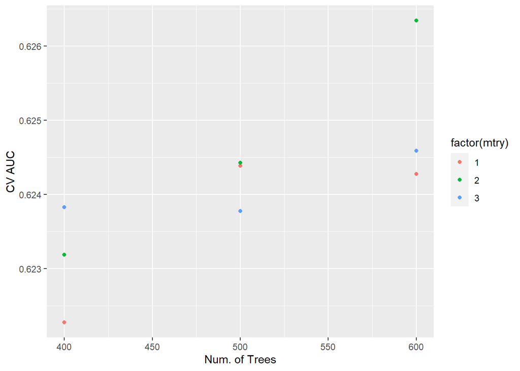

```r
# Visualize CV results
rf_fit |>
  collect_metrics() |>
  print(width = Inf) |>
  filter(.metric == "roc_auc") |>
  ggplot(mapping = aes(x = trees, y = mean, color = factor(mtry))) +
  geom_point() +
  labs(x = "Num. of Trees", y = "CV AUC")
```

```r
# Show the best 5 model
rf_fit |>
  show_best("roc_auc")
```

```
# A tibble: 5 × 8
   mtry trees .metric .estimator  mean     n std_err .config
  <int> <int> <chr>   <chr>      <dbl> <int>   <dbl> <chr>
1     2   600 roc_auc binary     0.626     3 0.00295 Preprocessor1_Model6
2     3   600 roc_auc binary     0.625     3 0.00256 Preprocessor1_Model9
3     2   500 roc_auc binary     0.624     3 0.00328 Preprocessor1_Model5
4     1   500 roc_auc binary     0.624     3 0.00291 Preprocessor1_Model2
5     1   600 roc_auc binary     0.624     3 0.00290 Preprocessor1_Model3
```

```r
# Select the best model
best_rf <- rf_fit |>
  select_best("roc_auc")
best_rf
```

```
# A tibble: 1 × 3
   mtry trees .config
  <int> <int> <chr>
1     2   600 Preprocessor1_Model6
```

```r
# Final workflow
rf_final_wf <- rf_wf |>
  finalize_workflow(best_rf)
rf_final_wf
```

```
══ Workflow ════════════════════════════════════════════════════════════════════
Preprocessor: Recipe
Model: rand_forest()

── Preprocessor ────────────────────────────────────────────────────────────────
2 Recipe Steps

• step_impute_mode()
• step_zv()

── Model ───────────────────────────────────────────────────────────────────────
Random Forest Model Specification (classification)

Main Arguments:
  mtry = 2
  trees = 600

Engine-Specific Arguments:
  importance = impurity

Computational engine: ranger
```

```r
# Fit the whole training set, then predict the test cases
if (file.exists("rf_final_fit.rds")) {
  rf_final_fit <- read_rds("rf_final_fit.rds")
} else {
  rf_final_fit <- rf_final_wf |>
    last_fit(data_split)
  write_rds(rf_final_fit, "rf_final_fit.rds")
}

rf_final_fit
```

```
# Resampling results
# Manual resampling
# A tibble: 1 × 6
  splits                id             .metrics .notes   .predictions .workflow
  <list>                <chr>          <list>   <list>   <list>       <list>
1 <split [36590/36591]> train/test sp… <tibble> <tibble> <tibble>     <workflow>
```

```r
# Test metrics
rf_final_fit |>
  collect_metrics()
```

```
# A tibble: 2 × 4
  .metric  .estimator .estimate .config
  <chr>    <chr>          <dbl> <chr>
1 accuracy binary         0.592 Preprocessor1_Model1
2 roc_auc  binary         0.629 Preprocessor1_Model1
```

### Boosting

```r
boost_recipe <-
  recipe(
    los_long ~ .,
    data = icu_train
  ) |>
  # mode imputation for categorical_var
  step_impute_mode(all_nominal_predictors()) |>
  # create traditional dummy variables (necessary for xgboost)
  step_dummy(all_nominal_predictors()) |>
  # zero-variance filter
  step_zv(all_numeric_predictors())
boost_recipe
```

```
── Recipe ──────────────────────────────────────────────────────────────────────
```

```
── Inputs
```

```
Number of variables by role
```

```
outcome:    1
predictor: 20
```

```
── Operations
```

```
• Mode imputation for: all_nominal_predictors()
```

```
• Dummy variables from: all_nominal_predictors()
```

```
• Zero variance filter on: all_numeric_predictors()
```

```r
# Model
boost_mod <-
  boost_tree(
    mode = "classification",
    trees = 400,
    tree_depth = tune(),
    learn_rate = tune()
  ) |>
  set_engine("xgboost")
boost_mod
```

```
Boosted Tree Model Specification (classification)

Main Arguments:
  trees = 400
  tree_depth = tune()
  learn_rate = tune()

Computational engine: xgboost
```

```r
# Workflow
boost_wf <- workflow() |>
  add_recipe(boost_recipe) |>
  add_model(boost_mod)
boost_wf
```

```
══ Workflow ════════════════════════════════════════════════════════════════════
Preprocessor: Recipe
Model: boost_tree()

── Preprocessor ────────────────────────────────────────────────────────────────
3 Recipe Steps

• step_impute_mode()
• step_dummy()
• step_zv()

── Model ───────────────────────────────────────────────────────────────────────
Boosted Tree Model Specification (classification)

Main Arguments:
  trees = 400
  tree_depth = tune()
  learn_rate = tune()

Computational engine: xgboost
```

```r
# Tuning grid
boost_param_grid <- grid_regular(
  tree_depth(range = c(2L, 3L)),
  learn_rate(range = c(-2, 0), trans = log10_trans()),
  levels = c(2, 5)
  )
boost_param_grid
```

```
# A tibble: 10 × 2
   tree_depth learn_rate
        <int>      <dbl>
 1          2     0.01
 2          3     0.01
 3          2     0.0316
 4          3     0.0316
 5          2     0.1
 6          3     0.1
 7          2     0.316
 8          3     0.316
 9          2     1
10          3     1
```

```r
# Fit cross-validation (boosting)
set.seed(203)
if (file.exists("boost_fit.rds")) {
  boost_fit <- read_rds("boost_fit.rds")
} else {
  boost_fit <- boost_wf |>
    tune_grid(
      resamples = folds,
      grid = boost_param_grid,
      metrics = metric_set(roc_auc, accuracy),
      control = control_stack_grid()
      )
  write_rds(boost_fit, "boost_fit.rds")
}
boost_fit
```

```
# Tuning results
# 3-fold cross-validation
# A tibble: 3 × 5
  splits                id    .metrics          .notes           .predictions
  <list>                <chr> <list>            <list>           <list>
1 <split [24393/12197]> Fold1 <tibble [20 × 6]> <tibble [0 × 3]> <tibble>
2 <split [24393/12197]> Fold2 <tibble [20 × 6]> <tibble [0 × 3]> <tibble>
3 <split [24394/12196]> Fold3 <tibble [20 × 6]> <tibble [0 × 3]> <tibble>
```

```
# A tibble: 20 × 8
   tree_depth learn_rate .metric  .estimator  mean     n  std_err
        <int>      <dbl> <chr>    <chr>      <dbl> <int>    <dbl>
 1          2     0.01   accuracy binary     0.575     3 0.00349
 2          2     0.01   roc_auc  binary     0.612     3 0.00283
 3          3     0.01   accuracy binary     0.584     3 0.00183
 4          3     0.01   roc_auc  binary     0.620     3 0.00322
 5          2     0.0316 accuracy binary     0.584     3 0.00169
 6          2     0.0316 roc_auc  binary     0.621     3 0.00216
 7          3     0.0316 accuracy binary     0.586     3 0.00177
 8          3     0.0316 roc_auc  binary     0.625     3 0.00251
 9          2     0.1    accuracy binary     0.585     3 0.00200
10          2     0.1    roc_auc  binary     0.623     3 0.00207
11          3     0.1    accuracy binary     0.588     3 0.00156
12          3     0.1    roc_auc  binary     0.623     3 0.00143
```

[output cut: 30 more lines]

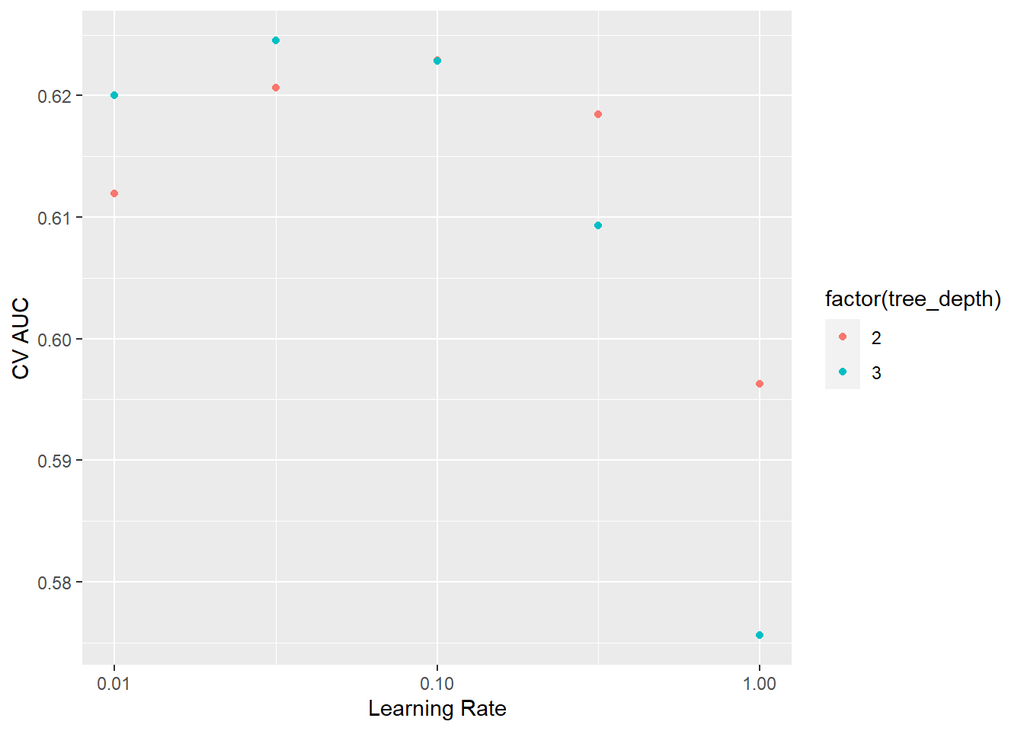

```r
# Visualize CV results
boost_fit |>
  collect_metrics() |>
  print(width = Inf) |>
  filter(.metric == "roc_auc") |>
  ggplot(mapping = aes(x = learn_rate, y = mean, color = factor(tree_depth))) +
  geom_point() +
  labs(x = "Learning Rate", y = "CV AUC") +
  scale_x_log10()
```

```r
# Show the best 5 model
boost_fit |>
  show_best("roc_auc")
```

```
# A tibble: 5 × 8
  tree_depth learn_rate .metric .estimator  mean     n std_err .config
       <int>      <dbl> <chr>   <chr>      <dbl> <int>   <dbl> <chr>
1          3     0.0316 roc_auc binary     0.625     3 0.00251 Preprocessor1_Mo…
2          2     0.1    roc_auc binary     0.623     3 0.00207 Preprocessor1_Mo…
3          3     0.1    roc_auc binary     0.623     3 0.00143 Preprocessor1_Mo…
4          2     0.0316 roc_auc binary     0.621     3 0.00216 Preprocessor1_Mo…
5          3     0.01   roc_auc binary     0.620     3 0.00322 Preprocessor1_Mo…
```

```r
# Select the best model
best_boost <- boost_fit |>
  select_best("roc_auc")
best_boost
```

```
# A tibble: 1 × 3
  tree_depth learn_rate .config
       <int>      <dbl> <chr>
1          3     0.0316 Preprocessor1_Model04
```

```r
# Final workflow
boost_final_wf <- boost_wf |>
  finalize_workflow(best_boost)
boost_final_wf
```

```
══ Workflow ════════════════════════════════════════════════════════════════════
Preprocessor: Recipe
Model: boost_tree()

── Preprocessor ────────────────────────────────────────────────────────────────
3 Recipe Steps

• step_impute_mode()
• step_dummy()
• step_zv()

── Model ───────────────────────────────────────────────────────────────────────
Boosted Tree Model Specification (classification)

Main Arguments:
  trees = 400
  tree_depth = 3
  learn_rate = 0.0316227766016838

Computational engine: xgboost
```

```r
# Fit the whole training set, then predict the test cases
if (file.exists("boost_final_fit.rds")) {
  boost_final_fit <- read_rds("boost_final_fit.rds")
} else {
  boost_final_fit <- boost_final_wf |>
    last_fit(data_split) |>
    write_rds("boost_final_fit.rds")
}
boost_final_fit
```

```
# Resampling results
# Manual resampling
# A tibble: 1 × 6
  splits                id             .metrics .notes   .predictions .workflow
  <list>                <chr>          <list>   <list>   <list>       <list>
1 <split [36590/36591]> train/test sp… <tibble> <tibble> <tibble>     <workflow>
```

```r
# Test metrics
boost_final_fit |>
  collect_metrics()
```

```
# A tibble: 2 × 4
  .metric  .estimator .estimate .config
  <chr>    <chr>          <dbl> <chr>
1 accuracy binary         0.590 Preprocessor1_Model1
2 roc_auc  binary         0.626 Preprocessor1_Model1
```

### Model stacking

```r
# Model stacking
if (!file.exists("icu_model_st.rds")) {
  icu_model_st <-
    # initialize the stack
    stacks() |>
    # add candidate members
    add_candidates(logit_fit) |>
    add_candidates(rf_fit) |>
    add_candidates(boost_fit) |>
    # determine how to combine their predictions
    blend_predictions(
      penalty = 10^(-4:-1),
      metrics = c("roc_auc"),
      times = 3
      ) |>
    # fit the candidates with nonzero stacking coefficients
    fit_members()
  saveRDS(icu_model_st, "icu_model_st.rds")
} else {
  icu_model_st <- read_rds("icu_model_st.rds")
}
```

```r
icu_model_st
```

```
── A stacked ensemble model ─────────────────────────────────────


Out of 27 possible candidate members, the ensemble retained 12.

Penalty: 1e-04.

Mixture: 1.


The 10 highest weighted member classes are:
```

```
# A tibble: 10 × 3
   member                    type         weight
   <chr>                     <chr>         <dbl>
 1 .pred_TRUE_rf_fit_1_6     rand_forest   1.49
 2 .pred_TRUE_logit_fit_1_01 logistic_reg  0.756
 3 .pred_TRUE_rf_fit_1_7     rand_forest   0.614
 4 .pred_TRUE_boost_fit_1_04 boost_tree    0.561
 5 .pred_TRUE_rf_fit_1_2     rand_forest   0.538
 6 .pred_TRUE_rf_fit_1_9     rand_forest   0.459
 7 .pred_TRUE_boost_fit_1_06 boost_tree    0.439
 8 .pred_TRUE_rf_fit_1_8     rand_forest   0.310
 9 .pred_TRUE_boost_fit_1_07 boost_tree    0.166
10 .pred_TRUE_boost_fit_1_08 boost_tree    0.144
```

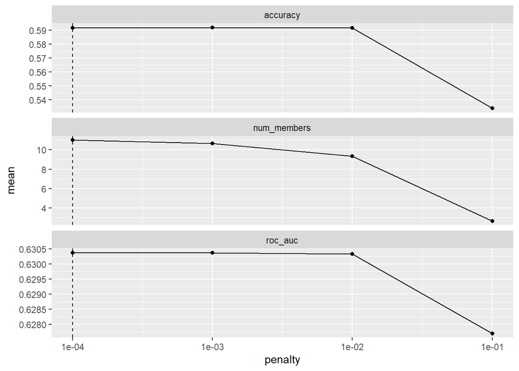

```r
autoplot(icu_model_st)
```

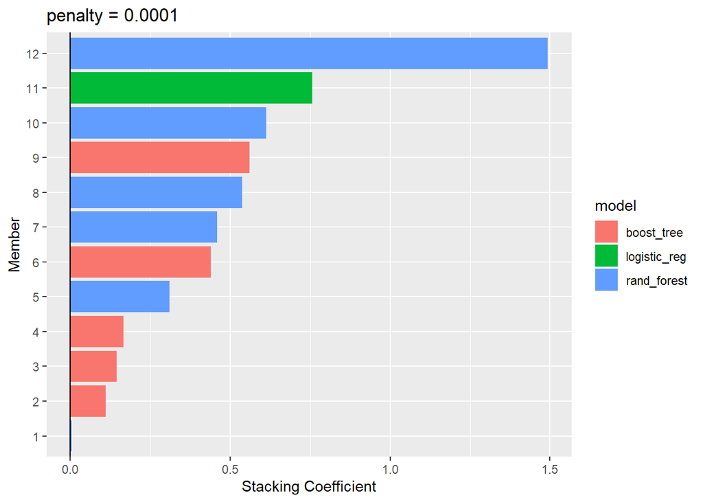

```r
# To see the top results
autoplot(icu_model_st, type = "weights")
```

```r
# To identify which model configurations were assigned what stacking coefficients
collect_parameters(icu_model_st, "rf_fit")
```

```
# A tibble: 9 × 5
  member      mtry trees terms                    coef
  <chr>      <int> <int> <chr>                   <dbl>
1 rf_fit_1_1     1   400 .pred_TRUE_rf_fit_1_1 0
2 rf_fit_1_2     1   500 .pred_TRUE_rf_fit_1_2 0.538
3 rf_fit_1_3     1   600 .pred_TRUE_rf_fit_1_3 0.00452
4 rf_fit_1_4     2   400 .pred_TRUE_rf_fit_1_4 0
5 rf_fit_1_5     2   500 .pred_TRUE_rf_fit_1_5 0
6 rf_fit_1_6     2   600 .pred_TRUE_rf_fit_1_6 1.49
7 rf_fit_1_7     3   400 .pred_TRUE_rf_fit_1_7 0.614
8 rf_fit_1_8     3   500 .pred_TRUE_rf_fit_1_8 0.310
9 rf_fit_1_9     3   600 .pred_TRUE_rf_fit_1_9 0.459
```

```r
collect_parameters(icu_model_st, "logit_fit")
```

```
# A tibble: 8 × 5
  member         penalty mixture terms                      coef
  <chr>            <dbl>   <dbl> <chr>                     <dbl>
1 logit_fit_1_01 0.00316       0 .pred_TRUE_logit_fit_1_01 0.756
2 logit_fit_1_04 0.00750       0 .pred_TRUE_logit_fit_1_04 0
3 logit_fit_1_05 0.01          0 .pred_TRUE_logit_fit_1_05 0
4 logit_fit_1_06 0.00316       1 .pred_TRUE_logit_fit_1_06 0
5 logit_fit_1_07 0.00422       1 .pred_TRUE_logit_fit_1_07 0
6 logit_fit_1_08 0.00562       1 .pred_TRUE_logit_fit_1_08 0
7 logit_fit_1_09 0.00750       1 .pred_TRUE_logit_fit_1_09 0
8 logit_fit_1_10 0.01          1 .pred_TRUE_logit_fit_1_10 0
```

```r
collect_parameters(icu_model_st, "boost_fit")
```

```
# A tibble: 10 × 5
   member         tree_depth learn_rate terms                      coef
   <chr>               <int>      <dbl> <chr>                     <dbl>
 1 boost_fit_1_01          2     0.01   .pred_TRUE_boost_fit_1_01 0
 2 boost_fit_1_02          3     0.01   .pred_TRUE_boost_fit_1_02 0
 3 boost_fit_1_03          2     0.0316 .pred_TRUE_boost_fit_1_03 0
 4 boost_fit_1_04          3     0.0316 .pred_TRUE_boost_fit_1_04 0.561
 5 boost_fit_1_05          2     0.1    .pred_TRUE_boost_fit_1_05 0
 6 boost_fit_1_06          3     0.1    .pred_TRUE_boost_fit_1_06 0.439
 7 boost_fit_1_07          2     0.316  .pred_TRUE_boost_fit_1_07 0.166
 8 boost_fit_1_08          3     0.316  .pred_TRUE_boost_fit_1_08 0.144
 9 boost_fit_1_09          2     1      .pred_TRUE_boost_fit_1_09 0.110
10 boost_fit_1_10          3     1      .pred_TRUE_boost_fit_1_10 0
```

```r
# Final classfication for stacking method
stack_icu_pred <- icu_test %>%
  bind_cols(predict(icu_model_st, ., type = "prob")) %>%
  print(width = Inf)
```

```
# A tibble: 36,591 × 23
   los_long first_careunit
   <fct>    <fct>
 1 FALSE    Medical Intensive Care Unit (MICU)
 2 FALSE    Surgical Intensive Care Unit (SICU)
 3 FALSE    Surgical Intensive Care Unit (SICU)
 4 FALSE    Medical/Surgical Intensive Care Unit (MICU/SICU)
 5 FALSE    Cardiac Vascular Intensive Care Unit (CVICU)
 6 TRUE     Other
 7 TRUE     Medical Intensive Care Unit (MICU)
 8 TRUE     Medical Intensive Care Unit (MICU)
 9 TRUE     Other
10 TRUE     Other
   admission_type              marital_status race  gender   age insurance
   <fct>                       <fct>          <fct> <fct>  <int> <fct>
```

[output cut: 59 more lines]

## 4. Compare model classification performance on the test set.

Report both the area under ROC curve and accuracy for each machine learning algorithm and the model stacking. Interpret the results. What are the most important features in predicting long ICU stays? How do the models compare in terms of performance and interpretability?

```r
# Test metrics for logistic regression model
logit_final_fit |>
  collect_metrics()
```

```
# A tibble: 2 × 4
  .metric  .estimator .estimate .config
  <chr>    <chr>          <dbl> <chr>
1 accuracy binary         0.573 Preprocessor1_Model1
2 roc_auc  binary         0.604 Preprocessor1_Model1
```

**Interpretation:** Logistic Regression shows an AUC of 0.604 and an accuracy of 57.3%, its performance is relatively low. However, its simplicity makes it the most interpretable model, offering straightforward insights into how features affect predictions.

AUC Score: measures a model’s ability to distinguish between classes. A higher AUC indicates a model with a better performance in terms of sensitivity (true positive rate) and specificity (true negative rate).

Accuracy: measures the proportion of true results (both true positives and true negatives) in the total dataset. It is a straightforward metric for overall performance but can be misleading if classes are imbalanced.

```r
# Test metrics for random forest model
rf_final_fit |>
  collect_metrics()
```

```
# A tibble: 2 × 4
  .metric  .estimator .estimate .config
  <chr>    <chr>          <dbl> <chr>
1 accuracy binary         0.592 Preprocessor1_Model1
2 roc_auc  binary         0.629 Preprocessor1_Model1
```

**Interpretation:** Random Forest shows an AUC of 0.629 and an accuracy of 59.2%, outperforming logistic regression. However, its complexity makes it less interpretable than logistic regression.

```r
# Test metrics for boosting model
boost_final_fit |>
  collect_metrics()
```

```
# A tibble: 2 × 4
  .metric  .estimator .estimate .config
  <chr>    <chr>          <dbl> <chr>
1 accuracy binary         0.590 Preprocessor1_Model1
2 roc_auc  binary         0.626 Preprocessor1_Model1
```

**Interpretation:** Boosting shows an AUC of 0.626 and an accuracy of 59%, performing better than logistic regression and slightly worse than random forest. It is also less interpretable due to its complexity.

```r
# Convert prediction estimates to factor based on the chosen threshold
stack_icu_pred <- stack_icu_pred |>
  mutate(
    .pred_class = if_else(.pred_FALSE >= 0.5, "FALSE", "TRUE"),
    .pred_class = factor(.pred_class, levels = c("FALSE", "TRUE"))
  )

# Test metrics for stacking model
roc_auc_value <- yardstick::roc_auc(
  stack_icu_pred,
  truth = los_long,
  contains(".pred_FALSE")
)

accuracy_value <- yardstick::accuracy(
  stack_icu_pred,
  truth = los_long,
  estimate = .pred_class
)

# Print both metrics
print(roc_auc_value)
```

```
# A tibble: 1 × 3
  .metric .estimator .estimate
  <chr>   <chr>          <dbl>
1 roc_auc binary         0.634
```

```r
print(accuracy_value)
```

```
# A tibble: 1 × 3
  .metric  .estimator .estimate
  <chr>    <chr>          <dbl>
1 accuracy binary         0.594
```

**Interpretation:** The stacking model shows the best performance with an AUC of 0.634 and an accuracy of 59.4%, suggesting effective leveraging of the strengths of individual models, at the expense of interpretability.

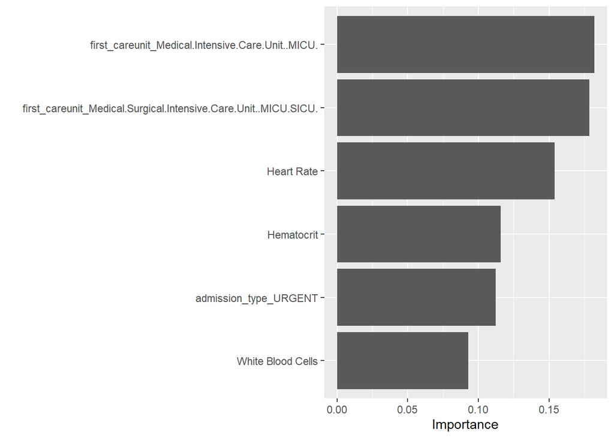

```r
# Extract important features for logistics regression model
logit_features <- extract_fit_engine(logit_final_fit) |>
  vip(num_features = 6)
logit_features
```

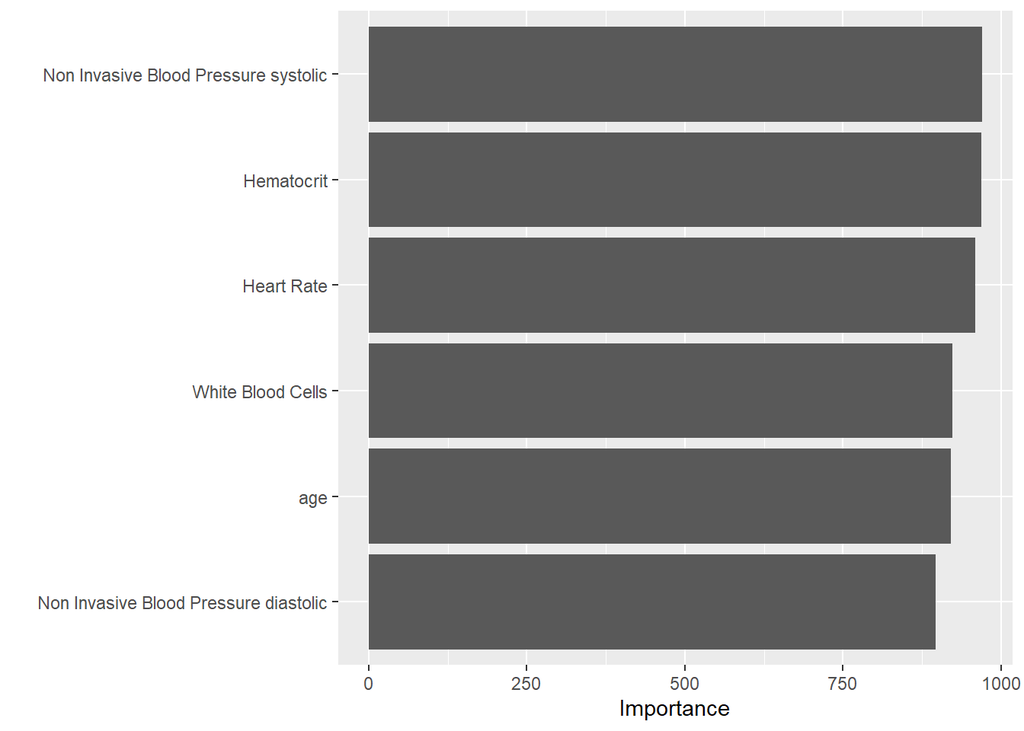

```r
# Extract important features for random forest model
rf_features <- extract_fit_engine(rf_final_fit) |>
  vip(num_features = 6)
rf_features
```

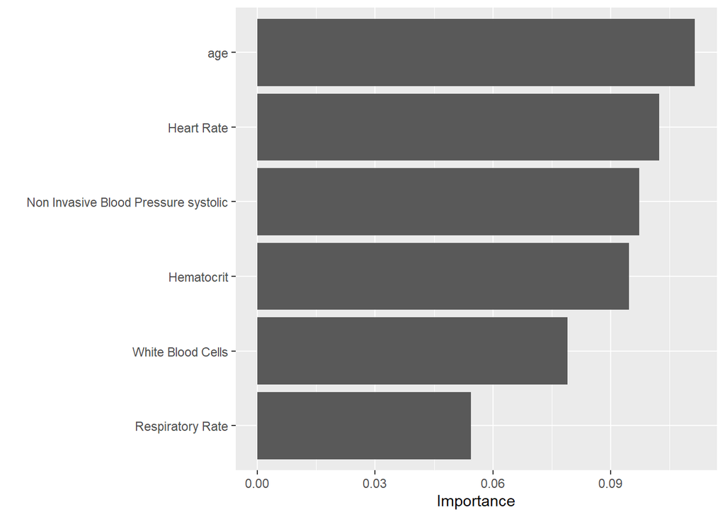

```r
# Extract important features for boosting model
boost_features <- extract_fit_engine(boost_final_fit) |>
  vip(num_features = 6)
boost_features
```

**Feature Importance for Predicting Long ICU Stays:**

The most important features vary by indivual models. But based on the above importance plots, we can conclude that variables such as patient age, Non Invasive Blood Pressure systolic, Heart Rate, Hematocrit and White Blood cells are important. Individually, the most important feature for logistic regression is first care unit, for random forest is Non Invasive Blood Pressure systolic, and for boosting is age.

**Comparison of Interpretability and complexity:**

The stacking model performs the best in accuracy (0.594) and AUC (0.634) but lacks interpretability due to its complexity.

Conversely, while logistic regression model is the most interpretable due to its simplicity and linearity, it has the lowest accuracy (0.573) and AUC (0.604). Random forest and XGBoost perform better logistic regression in terms of AUC and prediction accuracy but are less easy to interpret due to their complexity.